# Study_Materials--MIT Capstone Project

Problem Statement : You have been provided with a banking dataset that contains marketing insights for various campaigns that were run for the customers for a duration of time. Using your machine learning and analytical skills - provide actionable insights that will be useful for the company to plan striking and efficient marketing campaigns for their products. Dataset Information: Tasks To Be Performed: 1. Perform detailed EDA to obtain actionable insights for various features. 2. Perform Feature engineering and feature selection to reduce the noise from the data and prepare the data for data modeling. 3. Create a classification model using machine learning algorithms such as logistic regression, decision tree, random forest, etc. 4. Choose the best performing model, and optimize the efficiency of the model using hyperparameter tuning.

```python
import pandas as pd
import numpy as np
import matplotlib.pyplot as plt
import seaborn as sns
```

```python
df=pd.read_csv('train.csv',sep=";")
df.head(5)
```

|  | age | job | marital | education | default | balance | housing | loan | contact | day | month | duration | campaign | pdays | previous | poutcome | y |
| --- | --- | --- | --- | --- | --- | --- | --- | --- | --- | --- | --- | --- | --- | --- | --- | --- | --- |
| 0 | 58 | management | married | tertiary | no | 2143 | yes | no | unknown | 5 | may | 261 | 1 | -1 | 0 | unknown | no |
| 1 | 44 | technician | single | secondary | no | 29 | yes | no | unknown | 5 | may | 151 | 1 | -1 | 0 | unknown | no |
| 2 | 33 | entrepreneur | married | secondary | no | 2 | yes | yes | unknown | 5 | may | 76 | 1 | -1 | 0 | unknown | no |
| 3 | 47 | blue-collar | married | unknown | no | 1506 | yes | no | unknown | 5 | may | 92 | 1 | -1 | 0 | unknown | no |
| 4 | 33 | unknown | single | unknown | no | 1 | no | no | unknown | 5 | may | 198 | 1 | -1 | 0 | unknown | no |

EDA

```python
df.columns
```

```
Index(['age', 'job', 'marital', 'education', 'default', 'balance', 'housing',
       'loan', 'contact', 'day', 'month', 'duration', 'campaign', 'pdays',
       'previous', 'poutcome', 'y'],
      dtype='object')
```

```python
df.info()
```

```
<class 'pandas.core.frame.DataFrame'>
RangeIndex: 45211 entries, 0 to 45210
Data columns (total 17 columns):
 #   Column     Non-Null Count  Dtype
---  ------     --------------  -----
 0   age        45211 non-null  int64
 1   job        45211 non-null  object
 2   marital    45211 non-null  object
 3   education  45211 non-null  object
 4   default    45211 non-null  object
 5   balance    45211 non-null  int64
 6   housing    45211 non-null  object
 7   loan       45211 non-null  object
 8   contact    45211 non-null  object
 9   day        45211 non-null  int64
 10  month      45211 non-null  object
 11  duration   45211 non-null  int64
 12  campaign   45211 non-null  int64
 13  pdays      45211 non-null  int64
 14  previous   45211 non-null  int64
 15  poutcome   45211 non-null  object
 16  y          45211 non-null  object
dtypes: int64(7), object(10)
memory usage: 5.9+ MB
```

Dataset Information: Feature Name Description age: Age of the customer job: Profession of the customer marital :Marital status of the customer education: Educational qualification of the customer default:Does the customer have credit in default? balance: Average yearly balance housing:Does the customer have a housing loan? loan:Does the customer have a personal loan? contact:Contact communication type of the customer day:Last contact day of the month month:Last contact month of the year duration:Last contact duration in seconds campaign:Number of contacts during campaign pdays:Number of days since last contact previous:Number of contacts before campaign poutcome:Outcome of previous campaign y:Has the customer subscribed for a deposit?

```python
df.describe()
```

|  | age | balance | day | duration | campaign | pdays | previous |
| --- | --- | --- | --- | --- | --- | --- | --- |
| count | 45211.000000 | 45211.000000 | 45211.000000 | 45211.000000 | 45211.000000 | 45211.000000 | 45211.000000 |
| mean | 40.936210 | 1362.272058 | 15.806419 | 258.163080 | 2.763841 | 40.197828 | 0.580323 |
| std | 10.618762 | 3044.765829 | 8.322476 | 257.527812 | 3.098021 | 100.128746 | 2.303441 |
| min | 18.000000 | -8019.000000 | 1.000000 | 0.000000 | 1.000000 | -1.000000 | 0.000000 |
| 25% | 33.000000 | 72.000000 | 8.000000 | 103.000000 | 1.000000 | -1.000000 | 0.000000 |
| 50% | 39.000000 | 448.000000 | 16.000000 | 180.000000 | 2.000000 | -1.000000 | 0.000000 |
| 75% | 48.000000 | 1428.000000 | 21.000000 | 319.000000 | 3.000000 | -1.000000 | 0.000000 |
| max | 95.000000 | 102127.000000 | 31.000000 | 4918.000000 | 63.000000 | 871.000000 | 275.000000 |

Age:Maximum age is 95 and minimum age is 18 Balance:Maximum balance is 102127 and minimum balance is -8019

```python
df.corr()
```

|  | age | balance | day | duration | campaign | pdays | previous |
| --- | --- | --- | --- | --- | --- | --- | --- |
| age | 1.000000 | 0.097783 | -0.009120 | -0.004648 | 0.004760 | -0.023758 | 0.001288 |
| balance | 0.097783 | 1.000000 | 0.004503 | 0.021560 | -0.014578 | 0.003435 | 0.016674 |
| day | -0.009120 | 0.004503 | 1.000000 | -0.030206 | 0.162490 | -0.093044 | -0.051710 |
| duration | -0.004648 | 0.021560 | -0.030206 | 1.000000 | -0.084570 | -0.001565 | 0.001203 |
| campaign | 0.004760 | -0.014578 | 0.162490 | -0.084570 | 1.000000 | -0.088628 | -0.032855 |
| pdays | -0.023758 | 0.003435 | -0.093044 | -0.001565 | -0.088628 | 1.000000 | 0.454820 |
| previous | 0.001288 | 0.016674 | -0.051710 | 0.001203 | -0.032855 | 0.454820 | 1.000000 |

```python
df.shape
```

```
(45211, 17)
```

```python
print('There are {} observations with {} features'.format(df.shape[0],df.shape[1]))
```

```
There are 45211 observations with 17 features
```

```python
df.head(3)
```

|  | age | job | marital | education | default | balance | housing | loan | contact | day | month | duration | campaign | pdays | previous | poutcome | y |
| --- | --- | --- | --- | --- | --- | --- | --- | --- | --- | --- | --- | --- | --- | --- | --- | --- | --- |
| 0 | 58 | management | married | tertiary | no | 2143 | yes | no | unknown | 5 | may | 261 | 1 | -1 | 0 | unknown | no |
| 1 | 44 | technician | single | secondary | no | 29 | yes | no | unknown | 5 | may | 151 | 1 | -1 | 0 | unknown | no |
| 2 | 33 | entrepreneur | married | secondary | no | 2 | yes | yes | unknown | 5 | may | 76 | 1 | -1 | 0 | unknown | no |

CATEGORICAL VALUES

```python
cat=df.select_dtypes(include=object)
cat_cols=cat.columns
cat_features=list(cat_cols)
print(cat_features)
```

```
['job', 'marital', 'education', 'default', 'housing', 'loan', 'contact', 'month', 'poutcome', 'y']
```

```python
for i in cat_features:
    print("The feature is {} and the observations are {}".format(i,df[i].nunique()))
```

```
The feature is job and the observations are 12
The feature is marital and the observations are 3
The feature is education and the observations are 4
The feature is default and the observations are 2
The feature is housing and the observations are 2
The feature is loan and the observations are 2
The feature is contact and the observations are 3
The feature is month and the observations are 12
The feature is poutcome and the observations are 4
The feature is y and the observations are 2
```

```python
for i in cat_features:
    print("The count of Categorial Attributes is '{}' : \n".format(i.title()))
    print(df[i].value_counts().sort_index())
```

```
The count of Categorial Attributes is 'Job' :

admin.           5171
blue-collar      9732
entrepreneur     1487
housemaid        1240
management       9458
retired          2264
self-employed    1579
services         4154
student           938
technician       7597
unemployed       1303
unknown           288
Name: job, dtype: int64
The count of Categorial Attributes is 'Marital' :

divorced     5207
married     27214
single      12790
Name: marital, dtype: int64
The count of Categorial Attributes is 'Education' :

primary       6851
secondary    23202
tertiary     13301
unknown       1857
Name: education, dtype: int64
The count of Categorial Attributes is 'Default' :

no     44396
yes      815
Name: default, dtype: int64
The count of Categorial Attributes is 'Housing' :

no     20081
yes    25130
Name: housing, dtype: int64
The count of Categorial Attributes is 'Loan' :

```

[output cut: 21 more lines]

```
oct      738
sep      579
Name: month, dtype: int64
The count of Categorial Attributes is 'Poutcome' :

failure     4901
other       1840
success     1511
unknown    36959
Name: poutcome, dtype: int64
The count of Categorial Attributes is 'Y' :

no     39922
yes     5289
Name: y, dtype: int64
```

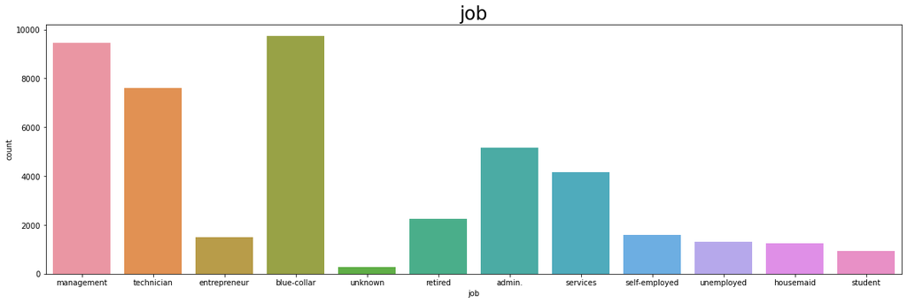

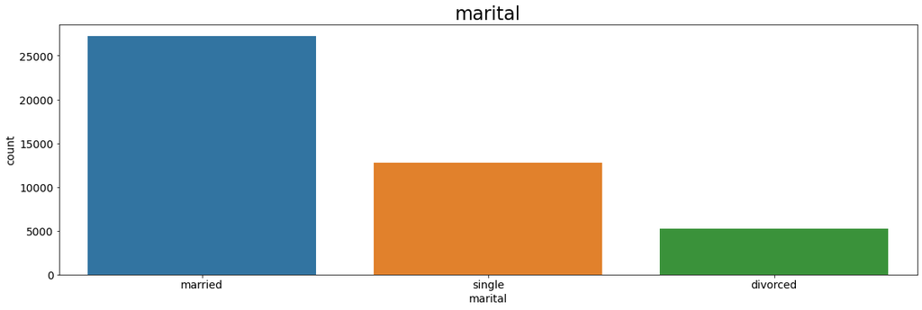

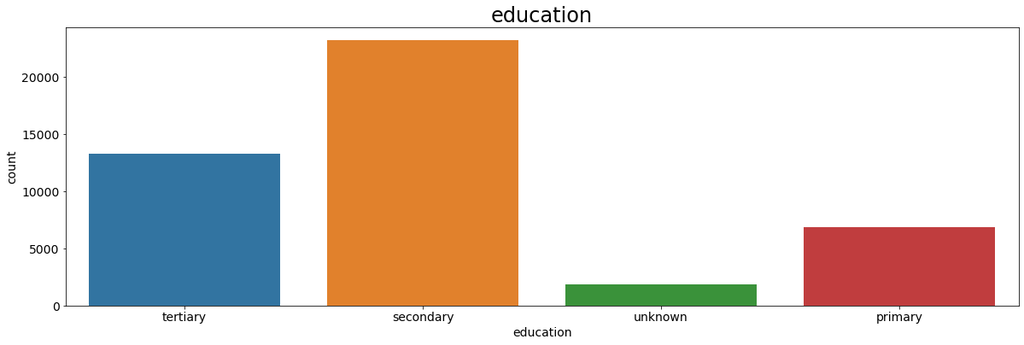

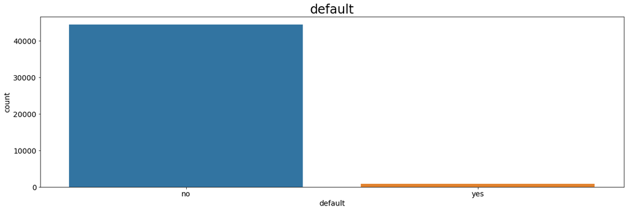

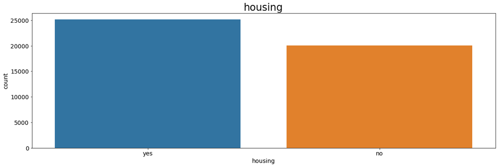

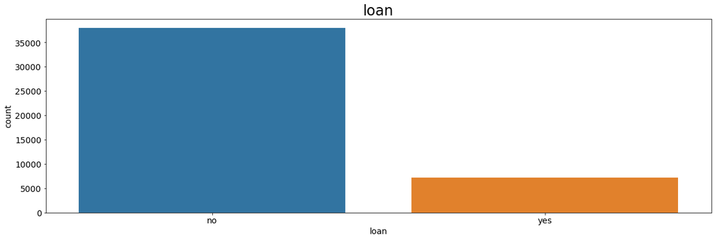

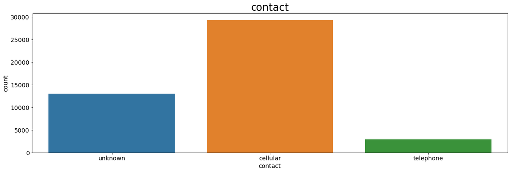

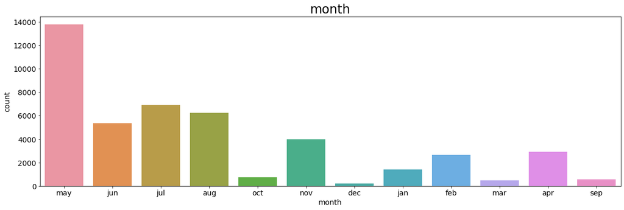

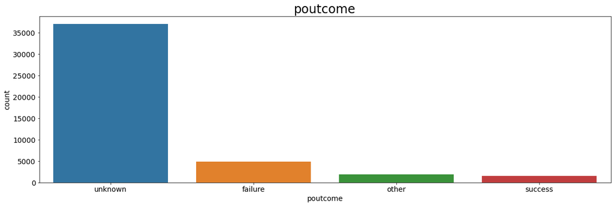

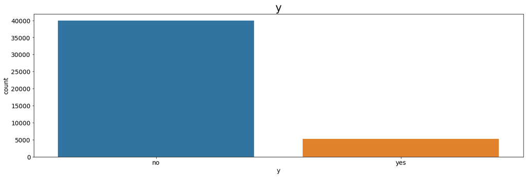

```python
for i in cat_features:
    fig=plt.subplots(figsize=(20,6))
    plt.rcParams.update({'font.size':20})
    data=df[i].value_counts()
    countplot=sns.countplot(x=i,data=df)
    plt.title(i)
    plt.rcParams.update({'font.size':14})
    plt.show()
    print('--------------------------------------------------------------------------------------------------------------------------------------------')
```

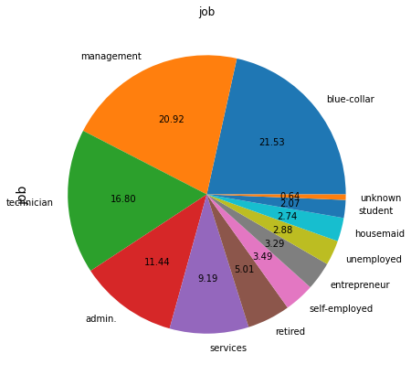

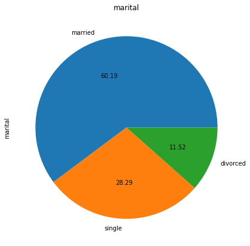

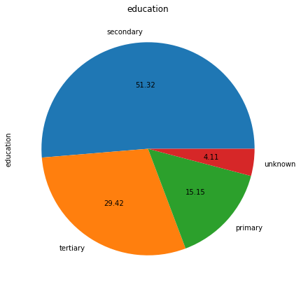

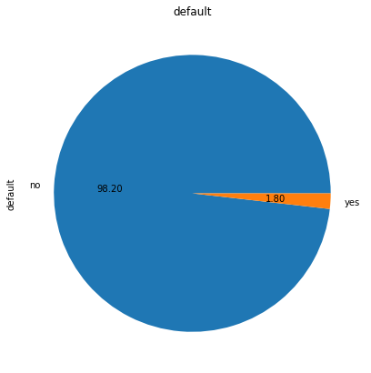

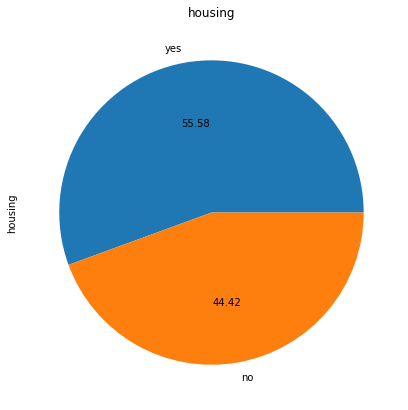

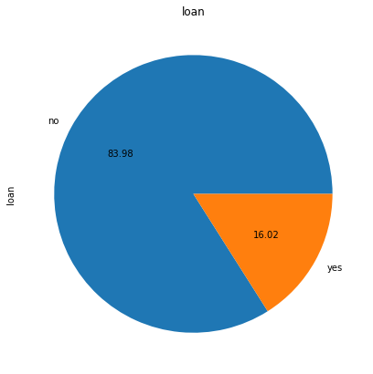

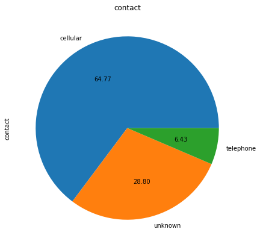

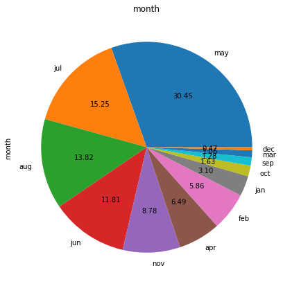

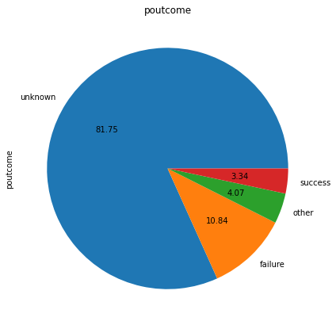

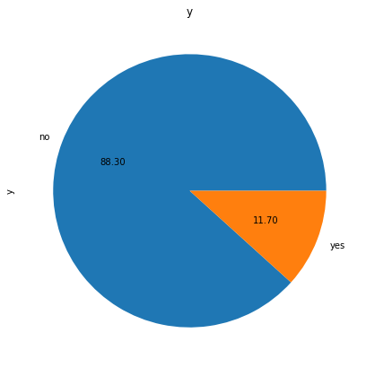

```python
for i in cat_features:
    fig=plt.subplots(figsize=(10,7))
    plt.rcParams.update({'font.size':10})
    data=df[i].value_counts()
    barplot=data.plot(kind='pie',fontsize=10,autopct='%.2f')
    plt.title(i)
    plt.show()
    print('------------------------------------------------------------------------------------------------------------------------')
```

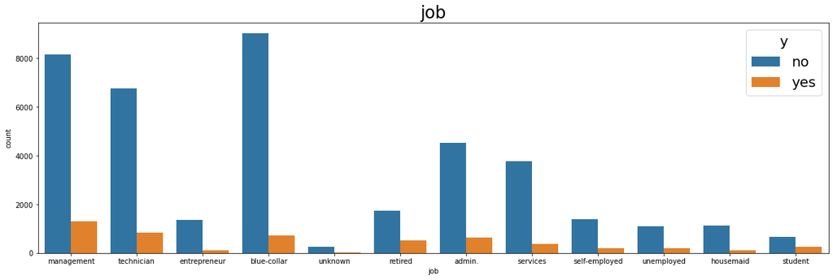

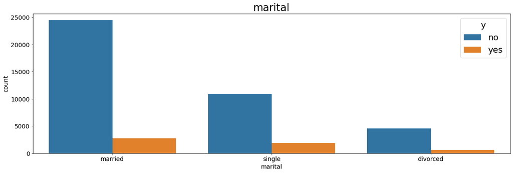

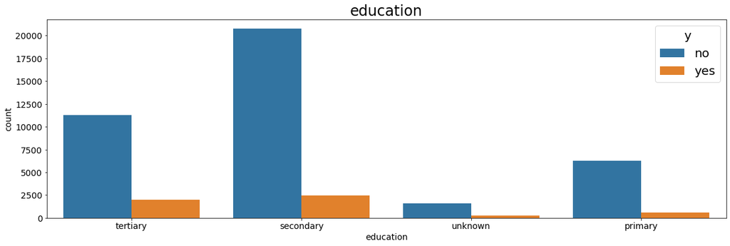

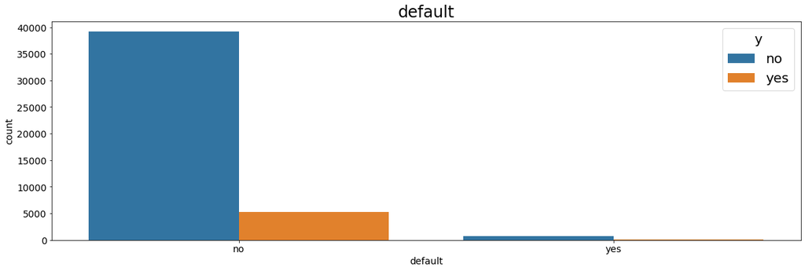

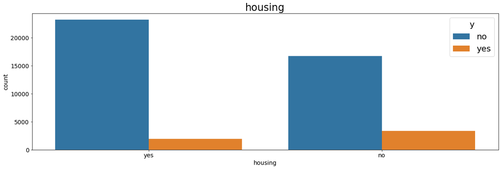

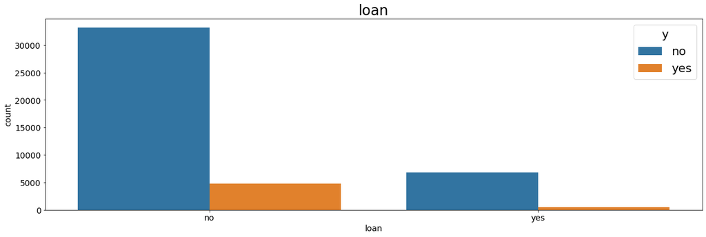

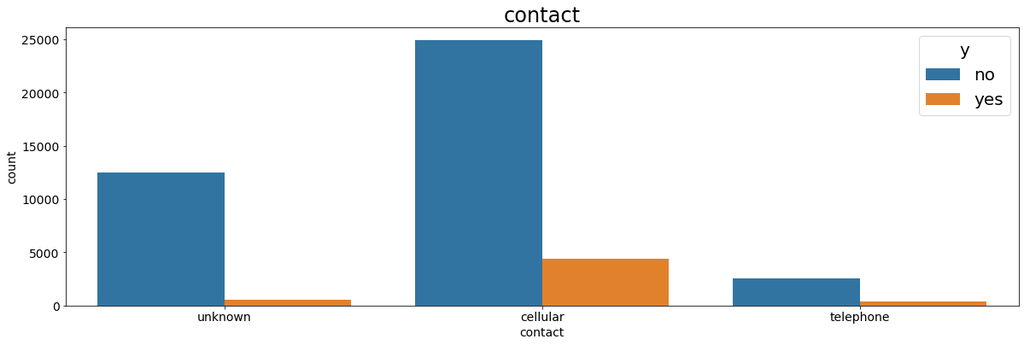

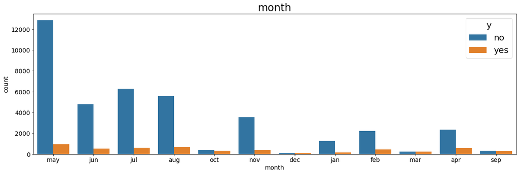

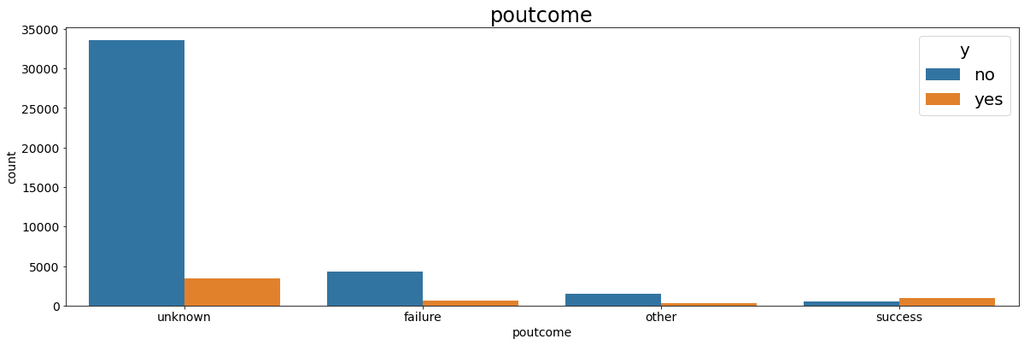

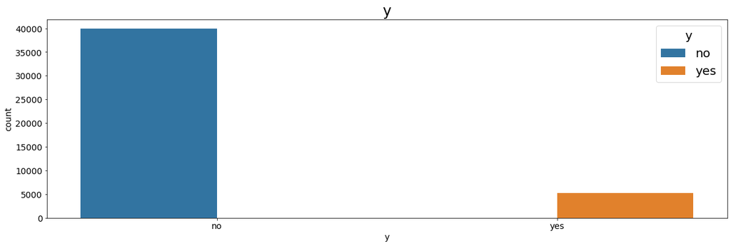

```python
for i in cat_features:
    fig=plt.subplots(figsize=(20,6))
    plt.rcParams.update({'font.size':20})
    data=df[i].value_counts()
    countplot=sns.countplot(x=i,data=df,hue='y')
    plt.title(i)
    plt.rcParams.update({'font.size':14})
    plt.show()
```

NUMERICAL VALUES

```python
num=df.select_dtypes(include=np.number)
num_cols=num.columns
num_features=list(num_cols)
print(num_features)
```

```
['age', 'balance', 'day', 'duration', 'campaign', 'pdays', 'previous']
```